# Week 01. Genome Analysis and Statistics

# Aim of this exercise

- Learn the basics of Rmarkdown (combining text and code)
- Learn how to load and install packages
- Try a really simple plot (ggplot)
- How to clear memory/Panic
- How to get help!
- Try the sample() function
- Analyse a small data set

You can embed an R code chunk like this:

Try the small “Run” button in the menu for this panel to see the different options for running the code

```r
dim(cars)
```

```
## [1] 50  2
```

The dim() function gives you the dimensions of the dataset.

You insert these chunks of code by pressing ctrl+alt+i or by the >Code>Insert chunk menu

> Q: Insert a chunk of code that uses the head() function to inspect the cars dataset

The head() function prints the first few lines of a data frame.

```r
head(cars)
```

```
##   speed dist
## 1     4    2
## 2     4   10
## 3     7    4
## 4     7   22
## 5     8   16
## 6     9   10
```

# Loading and/or installing packages

Install a package using the tools>install packages menu.

> Q: Install the tidyverse package(s)

For more info, visit https://www.tidyverse.org/

> Q: Install/update the rmarkdown package

If you have problems with installing packages, please try and ask fellow students.

If you continue to have problems ask your TA.

It normally helps to reinstall R and Rstudio.

Also it should be noted that both R and Rstudio affects your system very little and can easily be removed again.

> Q: Load the tidyverse package.

This will only work if you have successfully installed the tidyverse package(s).

You load packages with the library(packagename) function.

```r
library(tidyverse)
```

> Q: Try and knit this this document now!

Press the “knit button” or press ctrl+shift+k

# Show a plot

```r
names(pressure)
```

```
## [1] "temperature" "pressure"
```

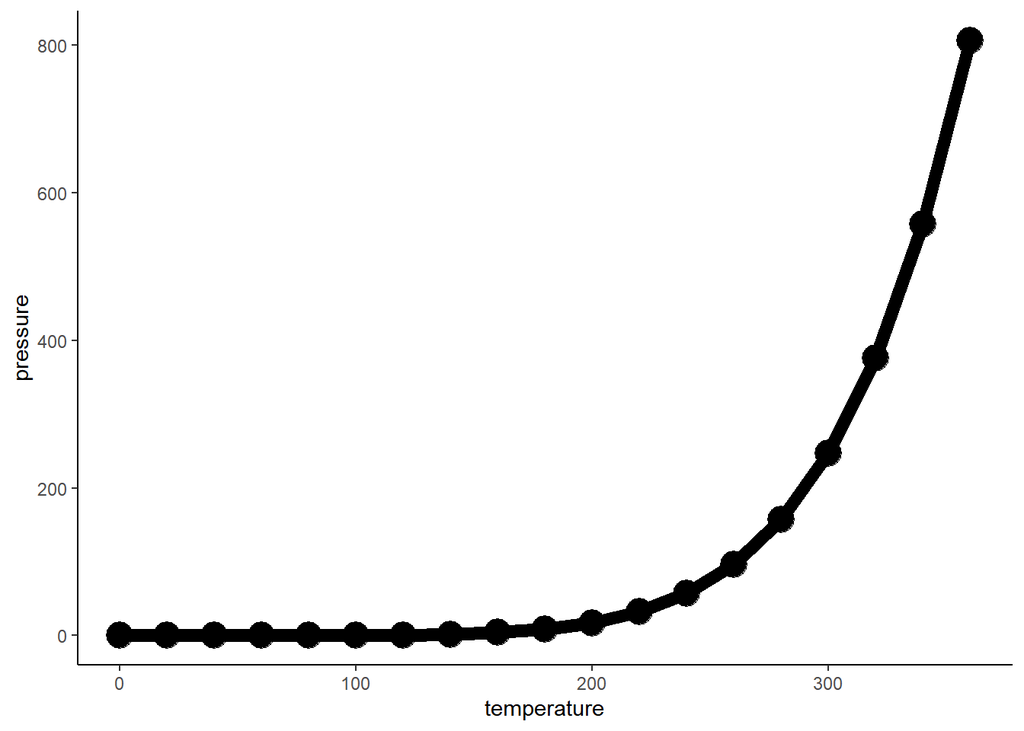

```r
ggplot(pressure, aes(x=temperature, y=pressure)) +
  geom_point(size=6) +
  geom_line(size=3) +
  theme_classic()
```

# Clear the console

You can clear the console using the Edit menu or the keyboard shortcut (found in the edit menu)

> Q: Clear the console

# Restarting the R session

You can restart R using the Session menu or the keyboard shortcut

> Q: Restart R and load the package tidyverse

```r
library(tidyverse)
```

# Getting help and loading data

You can get help using the “?” followed by function name

```r
?function
help(function)
```

> Q: Try and get some help for the “sample” function ###

```r
?sample
```

```
## starting httpd help server ... done
```

# The sample() function

```r
sample(x = 1:10, replace = TRUE)
```

```
##  [1]  7 10  1  7  5  1  9  9  9  2
```

```r
sample(x = 1:10, replace = FALSE)
```

```
##  [1]  1  5  3  8  4  2  6 10  9  7
```

```r
sample(x = 1:10, replace = TRUE)
```

```
##  [1]  8  6 10  5  3  6  2  3  1 10
```

> Q: What is the effect of replace=TRUE/FALSE?

## #removes data from set or not.

# Bird abundance data

You can load comma separated files using the read.csv() function

Here I load the birdAbundanceData dataset.

```r
birdAbundanceData <- read.csv(file = "chap02e2bDesertBirdAbundance.csv")

birdAbundanceData
```

```
##                    species abundance
## 1            Black Vulture        64
## 2           Turkey Vulture        23
## 3            Harris's Hawk         3
## 4          Red-tailed Hawk        16
## 5         American Kestrel         7
## 6           Gambel's Quail       148
## 7                Rock Dove         7
## 8        White-winged Dove       625
## 9            Mourning Dove       135
## 10      Greater Roadrunner         1
## 11        Great Horned Owl         2
## 12        Lesser Nighthawk        25
## 13 Black-chin. Hummingbird         1
## 14     Costa's Hummingbird         2
```

[output cut: 29 more lines]

NOTE the naming of the dataset #chap02e2b = chapter2, example 2 B = 2.2B

Get information about dataset

```r
summary(birdAbundanceData)
```

```
##    species            abundance
##  Length:43          Min.   :  1.00
##  Class :character   1st Qu.:  3.50
##  Mode  :character   Median : 18.00
##                     Mean   : 74.77
##                     3rd Qu.:102.50
##                     Max.   :625.00
```

Example of using basic statistical functions

```r
min(birdAbundanceData$abundance)
```

```
## [1] 1
```

```r
max(birdAbundanceData$abundance)
```

```
## [1] 625
```

> Q: Can you calculate the mean and median abundance of the dataset?

```r
mean(birdAbundanceData$abundance)
```

```
## [1] 74.76744
```

```r
median(birdAbundanceData$abundance)
```

```
## [1] 18
```

# Well done! Congratulations on reaching the end of week 1!